# **Project 3**, APS1070 Fall 2022

#### **PCA [14 marks]**

**Deadline: Nov 17, 21:00**

**Academic Integrity**

This project is individual - it is to be completed on your own. If you have questions, please post your query in the APS1070 Piazza Q&A forums (the answer might be useful to others!).

Do not share your code with others, or post your work online. Do not submit code that you have not written yourself. Students suspected of plagiarism on a project, midterm or exam will be referred to the department for formal discipline for breaches of the Student Code of Conduct.

Please fill out the following:

- **Name**: Kecheng Xiao
- **Student number**: 1008709140

### How to submit **(HTML + IPYNB)**

1. Download your notebook: `File -> Download .ipynb`
2. Click on the Files icon on the far left menu of Colab
3. Select & upload your `.ipynb` file you just downloaded, and then obtain its path (right click) (you might need to hit the Refresh button before your file shows up)
1. execute the following in a Colab cell:

   ```
   %%shell
   jupyter nbconvert --to html /PATH/TO/YOUR/NOTEBOOKFILE.ipynb
   ```

2. An HTML version of your notebook will appear in the files, so you can download it.
3. Submit **both** `HTML` and `IPYNB` files on Quercus for grading.

Ref: https://stackoverflow.com/a/64487858

In this project we work on a Covid-19 dataset that reports the number of confirmed cases per day and Fashion MNIST.

# Part 1: Getting started [2 Marks]

```python
import pandas as pd
import numpy as np
import matplotlib.pyplot as plt

cases_raw = pd.read_csv(
    filepath_or_buffer='https://raw.githubusercontent.com/aps1070-2019/datasets/master/APS_COVID_Jan22.csv',
    index_col=0,
    thousands=','
)
```

1. Write a function to do the following: **[0.5]**
   - Takes the dataframe, and your country list as inputs (US, China, Canada, ...)
   - Plots time-series for the input list (it is best to plot each country in a separate graph (subplot), so you can easily compare them.)
2. Apply `StandardScaler` to the data. Each day should have a `mean` of zero and a `StD` of 1. **[0.5]**
3. Run the function in `step 1` on the standardized dataset for the `US`, `China`, and `Canada`. **[0.5]**
4. Discuss the trends in the standardized time-series for the `US`, `Canada`, and `China`. What does it mean if the curve goes up or down (are the number of covid cases negative?) What does the sign of values indicate? **[0.5]**

```python
cases_raw
```

|  | 2020-01-22 | 2020-01-23 | 2020-01-24 | 2020-01-25 | 2020-01-26 | 2020-01-27 | 2020-01-28 | 2020-01-29 | 2020-01-30 | 2020-01-31 | ... | 2022-01-14 | 2022-01-15 | 2022-01-16 | 2022-01-17 | 2022-01-18 | 2022-01-19 | 2022-01-20 | 2022-01-21 | 2022-01-22 | 2022-01-23 |
| --- | --- | --- | --- | --- | --- | --- | --- | --- | --- | --- | --- | --- | --- | --- | --- | --- | --- | --- | --- | --- | --- |
| Afghanistan | 0 | 0 | 0 | 0 | 0 | 0 | 0 | 0 | 0 | 0 | ... | 158639 | 158678 | 158717 | 158826 | 158974 | 159070 | 159303 | 159516 | 159548 | 159649 |
| Albania | 0 | 0 | 0 | 0 | 0 | 0 | 0 | 0 | 0 | 0 | ... | 228777 | 230940 | 232637 | 233654 | 236486 | 239129 | 241512 | 244182 | 246412 | 248070 |
| Algeria | 0 | 0 | 0 | 0 | 0 | 0 | 0 | 0 | 0 | 0 | ... | 224979 | 225484 | 226057 | 226749 | 227559 | 228918 | 230470 | 232325 | 234536 | 236670 |
| Andorra | 0 | 0 | 0 | 0 | 0 | 0 | 0 | 0 | 0 | 0 | ... | 29888 | 29888 | 29888 | 29888 | 29888 | 29888 | 32201 | 33025 | 33025 | 33025 |
| Angola | 0 | 0 | 0 | 0 | 0 | 0 | 0 | 0 | 0 | 0 | ... | 93302 | 93524 | 93694 | 93974 | 94275 | 94779 | 95220 | 95676 | 95902 | 96582 |
| ... | ... | ... | ... | ... | ... | ... | ... | ... | ... | ... | ... | ... | ... | ... | ... | ... | ... | ... | ... | ... | ... |
| Vietnam | 0 | 2 | 2 | 2 | 2 | 2 | 2 | 2 | 2 | 2 | ... | 1991484 | 2007862 | 2023546 | 2023546 | 2062128 | 2078087 | 2094802 | 2110737 | 2126444 | 2141422 |
| West Bank and Gaza | 0 | 0 | 0 | 0 | 0 | 0 | 0 | 0 | 0 | 0 | ... | 474234 | 474234 | 474234 | 476328 | 477151 | 478084 | 479343 | 480583 | 480583 | 480583 |
| Yemen | 0 | 0 | 0 | 0 | 0 | 0 | 0 | 0 | 0 | 0 | ... | 10233 | 10233 | 10252 | 10352 | 10408 | 10449 | 10507 | 10585 | 10585 | 10585 |
| Zambia | 0 | 0 | 0 | 0 | 0 | 0 | 0 | 0 | 0 | 0 | ... | 293695 | 295028 | 296132 | 296817 | 298032 | 299172 | 299971 | 300587 | 301203 | 301630 |
| Zimbabwe | 0 | 0 | 0 | 0 | 0 | 0 | 0 | 0 | 0 | 0 | ... | 225637 | 225637 | 226078 | 226460 | 226460 | 226887 | 227552 | 227961 | 228179 | 228254 |

196 rows × 733 columns

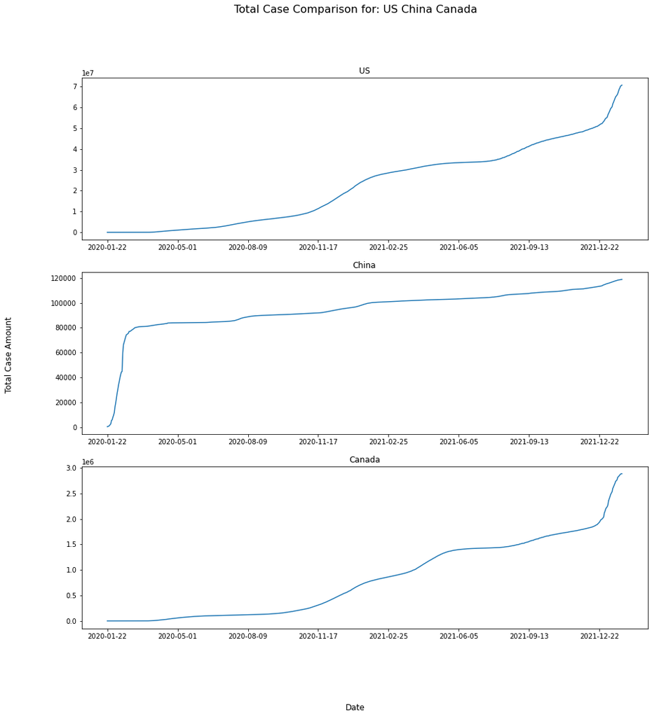

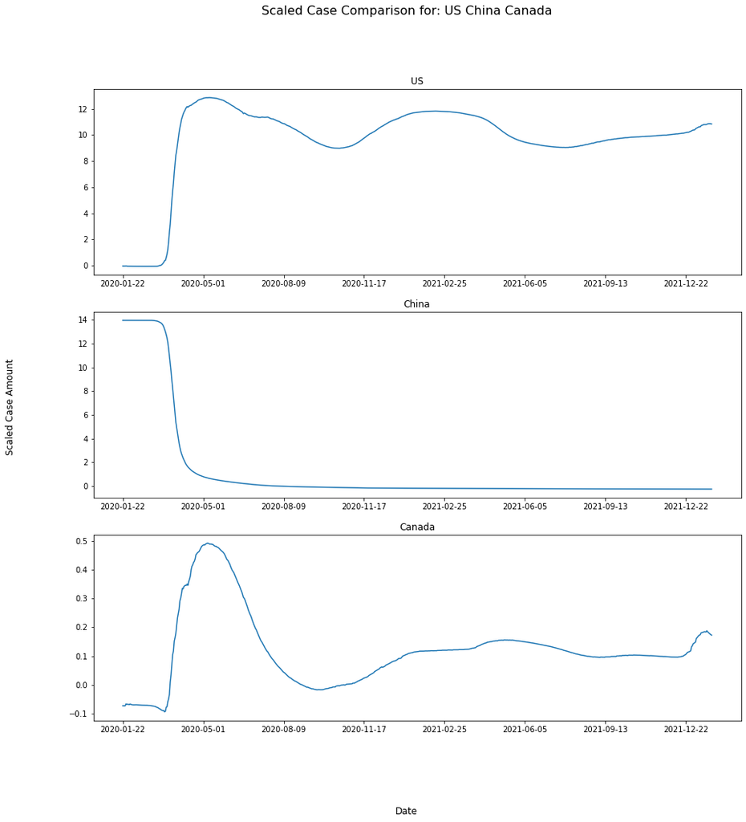

```python
from sklearn.preprocessing import StandardScaler

# 2 standard scalar and set y
scaler = StandardScaler()
cases_std = scaler.fit_transform(cases_raw)
cases_std = pd.DataFrame(cases_std, index=cases_raw.index)

# 1 function plots a time-series
def plot_case_by_country(c_ls, std=False):
    # input check
    for i in c_ls:
        assert i in cases_raw.index, 'Does not contain input country: '+i
    assert len(c_ls) >= 2, 'Input List should contain at least 2 Country Names.'
    # set x with dates
    x_date = cases_raw.columns
    # plot wit subplot()
    fig, axs = plt.subplots(len(c_ls), figsize=(15, 15))
    # set for standardized data
    if std:
        y_case = cases_std.T
    else:
        y_case = cases_raw.T
    for i in range(len(c_ls)):
        axs[i].plot(x_date, y_case[c_ls[i]])
        axs[i].xaxis.set_major_locator(plt.MaxNLocator(10))
        axs[i].set_title(c_ls[i])
    fig.supxlabel('Date')
    if std:
        fig.supylabel('Scaled Case Amount')
        fig.suptitle('Scaled Case Comparison for: '+' '.join(c_ls), fontsize=16)
    else:
        fig.supylabel('Total Case Amount')
        fig.suptitle('Total Case Comparison for: '+' '.join(c_ls), fontsize=16)
    plt.show()

# 1&3 run for 'US', 'China', 'Canada' as default
plot_case_by_country(c_ls=['US', 'China', 'Canada'])
plot_case_by_country(c_ls=['US', 'China', 'Canada'], std=True)
```

## Part 1.4: Answer

**1. The trend in US and Canada is quite similar at beginning with a rapid growth in 2020-03 to 2020-05, but only Canada has a huge decline after that. Then both US and Canada have small ups and downs. In comparison, China has a high amount at the very beginning, and it shows a sudden drop while US and Canada has the same the rise(in 2020-03 to 2020-05).

1. The up and down of the curve means how the number of national total cases change compare to worldwide, if the curve go up then the increasing number of covid cases in this country is faster than the world average, vice versa (because the world average is a flat line at 0). The actual covid cases will not be negative, but within the scaled dataset, the 0 means the average of covid cases globally. Therefore, if a point has a negative value, then in that day, the total national covid case number is below the world average.**

# Part 2: Applying PCA [3 Marks]

1. Compute the covariance matrix of the dataframe. *Hint: The dimensions of your covariance matrix should be (733, 733).* **[0.5]**
2. Write a function `get_sorted_eigen(df_cov)` that gets the covariance matrix of dataframe `df` (from step 1), and returns sorted eigenvalues and eigenvectors using `np.linalg.eigh`. **[0.5]**
3. Show the effectiveness of your principal components in covering the variance of the dataset with a `scree plot`(Bars for each component and a line to show cumulative --similar to tutorial. Limit x-axis if needed to better see the plot). **[0.5]**
4. How many PCs do you need to cover 98% of the dataset's variance? **[0.5]**
5. Plot the first 16 principal components (Eigenvectors) as a time series (16 subplots, on the x-axis you have dates and on the y-axis you have the value of the PC element) . **[0.5]**
6. Compare the first few PCs with the rest of them. Do you see any difference in their trend? **[0.5]**

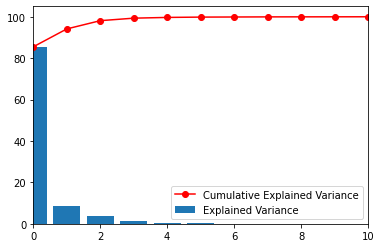

```
Part 2.4: Need 3 PCs to reach the 98% variance, which is: 98.08990311382456
```

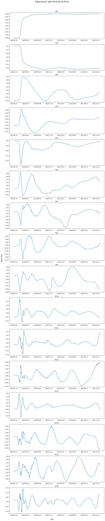

```python
import warnings
warnings.simplefilter("ignore", np.ComplexWarning)

# 1
df_cov_cases = np.dot(cases_std.T, cases_std)/(cases_std.shape[0]-1)

# 2
def get_sorted_eigen(df_cov):
    eigen_values, eigen_vectors = np.linalg.eigh(df_cov)
    args = (-eigen_values).argsort()
    return eigen_values[args], eigen_vectors[:, args]
# 3
eigenValues, eigenVectors = get_sorted_eigen(df_cov_cases)
eigValSum = sum(eigenValues)
expVar = [eigV/eigValSum*100 for eigV in eigenValues]
cumExpVar = np.cumsum(expVar)
plt.bar(range(733), expVar, label='Explained Variance')
plt.plot(cumExpVar, 'r-o', label='Cumulative Explained Variance')
plt.xlim(0,10)
plt.legend()
plt.show()
# 4
print('Part 2.4: Need 3 PCs to reach the 98% variance, which is:', cumExpVar[2])
# 5
def plot_eigen(pc_num=16):
    # set x with dates
    x_date = cases_raw.columns
    # plot wit subplot()
    fig, axs = plt.subplots(pc_num, figsize=(12, 60))

    for i in range(pc_num):
        axs[i].plot(x_date, eigenVectors[:,i])
        axs[i].xaxis.set_major_locator(plt.MaxNLocator(10))
        axs[i].set_title('PC'+str(i+1))
    fig.supxlabel('Date')
    fig.supylabel('Eigenvalue')
    fig.suptitle('Eigenvector with the first '+str(pc_num)+' PC(s)',  fontsize=16)
    fig.tight_layout(rect=[0.01, 0.01, 1, 0.97])
    plt.show()
plot_eigen()
```

## Part 2.6: Answer

**The first few PCs have very smooth curves and have almost no bump or few bumps(1-2), which means the first several PCs are capturing the most general trends in the dataset.**

# Part 3: Data reconstruction [5 Marks]

Create a function that:

- Accepts a country and the original dataset as inputs.
- Calls useful functions that you designed in previous parts to compute eigen vectors and eigen values.
- Plots 4 figures:
  1. The original time-series for the specified country. **[1]**
  2. The incremental reconstruction of the **original** (not standardized) time-series for the specified country in a single plot. **[1]**
     - You should at least show 5 curves in a figure for incremental reconstruction. For example, you can pick the following (or any other combination that you think is reasonable):
       - Reconstruction with only PC1
       - Reconstruction with both PC1 and PC2
       - Reconstruction with PC1 to PC4 (First 4 PCs)
       - Reconstruction with PC1 to PC8 (First 8 PCs)
       - Reconstruction with PC1 to PC16 (First 16 PCs)
     - Hint: you need to compute the reconstruction for the standardized time-series first, and then scale it back to the original (non-standardized form) using the StandardScaler `inverse_transform` [help...](https://scikit-learn.org/stable/modules/generated/sklearn.preprocessing.StandardScaler.html#sklearn.preprocessing.StandardScaler.inverse_transform)
  3. The residual error for your best reconstruction with respect to the original time-series. **[1]**
     - Hint: You are plotting the error that we have for reconstructing each day `(df - df_reconstructed)`. On the x-axis, you have dates, and on the y-axis, the residual error.
  4. The RMSE of the reconstruction as a function of the number of included components (x-axis is the number of components and y-axis is the RMSE). Sweep x-axis from 1 to 100 (this part is independent of part 3.2.) **[1]**

Test your function using the `US`, `Canada`, and `China` as inputs. **[1]**

```python
from sklearn.metrics import mean_squared_error

def plot_country_figures(original_df, country_name):
    line_count = 6
    # standard scalar and set y
    scaler_ = StandardScaler()
    df_std = scaler_.fit_transform(original_df)
    df_std = pd.DataFrame(df_std, index=original_df.index)
    # set x with dates, y with cases
    x_date = original_df.columns
    y_case = original_df.loc[country_name]
    # set x-axis showed
    x_date_display = range(0, cases_raw.shape[1], int(np.floor(cases_raw.shape[1]/8)))

    # 3.1 plot the original
    plt.figure(figsize=(16, 9))
    plt.plot(x_date, y_case, label='Original', linestyle='dashed', linewidth='4', color='black')
    plt.xticks(x_date_display)
    plt.xlabel('Date')
    plt.ylabel('Case Number')
    plt.ylim(min(y_case)-max(y_case)*0.05, max(y_case)*1.1)
    max_digit = len(str(int(max(y_case))))-1
    plt.ticklabel_format(axis='y', style='sci', scilimits=(max_digit, max_digit))
    plt.title('Original Plot in '+country_name,  fontsize=16)
    plt.legend()
    plt.show()
    # get eigen
    df_cov_ = np.dot(df_std.T, df_std)/(df_std.shape[0]-1)
    eigen_values, eigen_vectors = get_sorted_eigen(df_cov_)
    # set plot PC
    PC_count_ls = [0, 1, 3, 7, 15]

    # 3.2 plot PCs' reconstruction
    df_reconstructed = pd.DataFrame([])
    plt.figure(figsize=(16, 9))
    plt.plot(x_date, y_case, label='Original', linestyle='dashed', linewidth='4', color='black')
    for i in range(1, line_count):
        W = eigen_vectors[:, 0:PC_count_ls[i-1]+1]
        projX = np.dot(df_std.loc[country_name,:], W)
        ReconX = np.dot(projX, W.T)
        ReconX_original = scaler_.inverse_transform(ReconX.reshape(1,-1))
        # add reconstructed result to dataframe
        df_re = pd.DataFrame(ReconX_original.T.flatten(), columns=['to PC '+str(PC_count_ls[i-1]+1)])
        df_reconstructed = pd.concat([df_reconstructed, df_re], axis=1)
        # plot
        plt.plot(x_date, ReconX_original.T, label='to PC '+str(PC_count_ls[i-1]+1))
        plt.xticks(x_date_display)
    max_digit = len(str(int(max(y_case))))-1
    plt.ticklabel_format(axis='y', style='sci', scilimits=(max_digit, max_digit))
    plt.xlabel('Date')
    plt.ylabel('Case Number')
    max_digit = len(str(int(max(y_case))))-1
    plt.ticklabel_format(axis='y', style='sci', scilimits=(max_digit, max_digit))
    plt.ylim(min(y_case)-max(y_case)*0.05, max(y_case)*1.1)
    plt.title('Reconstruction with PCs in '+country_name,  fontsize=16)
    plt.legend()
    plt.show()
    df_reconstructed.set_index(original_df.columns, inplace=True)

    # 3.3 plot the reconstructed residual error
    plt.figure(figsize=(16, 9))
    i_min = np.argmin([sum(y_case.sub(df_reconstructed.iloc[:,i], axis='index')**2) for i in range(line_count-1)])
    plt.plot(x_date, y_case.sub(df_reconstructed.iloc[:,i_min], axis='index'), label='to PC '+str(PC_count_ls[i_min]+1))
    plt.xticks(x_date_display)
    max_digit = len(str(int(max(y_case.sub(df_reconstructed.iloc[:,i_min], axis='index')))))-1
    plt.ticklabel_format(axis='y', style='sci', scilimits=(max_digit, max_digit))
    plt.xlabel('Date')
    plt.ylabel('Residual Value')
    plt.title('Residual Plot of Reconstruction with PCs in '+country_name,  fontsize=16)
    plt.legend()
    plt.show()

    # 3.4 plot the RMSE with reconstruction
    rmse_ls = []
    plt.figure(figsize=(16, 9))
    for i in range(1, 101):
        W = eigen_vectors[:, 0:i]
        projX = np.dot(df_std.loc[country_name,:], W)
        ReconX = np.dot(projX, W.T)
        ReconX_original = scaler_.inverse_transform(ReconX.reshape(1,-1))
        rmse_ls.append(mean_squared_error(y_case, ReconX_original.T, squared=False))
    plt.plot(range(1,101), rmse_ls)
    max_digit = len(str(int(max(rmse_ls))))-1
    plt.ticklabel_format(axis='y', style='sci', scilimits=(max_digit, max_digit))
    plt.xlabel('PC Count')
    plt.ylabel('RMSE')
    plt.title('RMSE Plot of Reconstruction 1-100 PCs in '+country_name,  fontsize=16)
    plt.show()
```

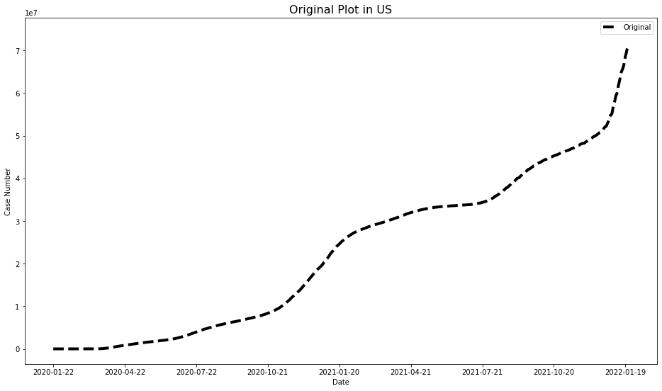

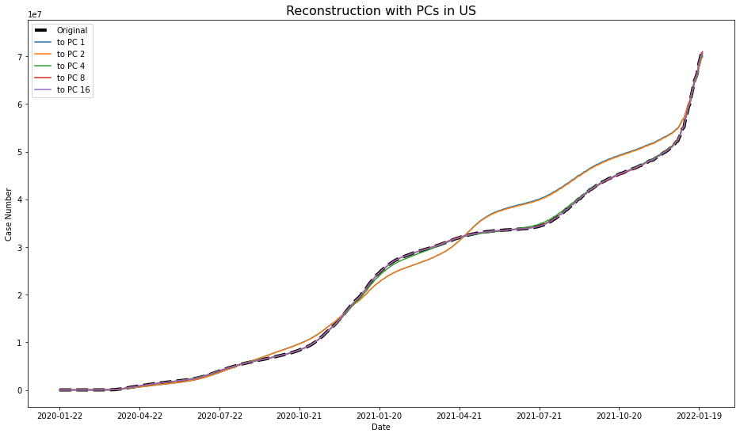

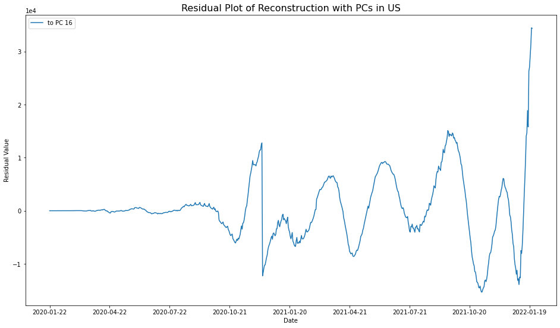

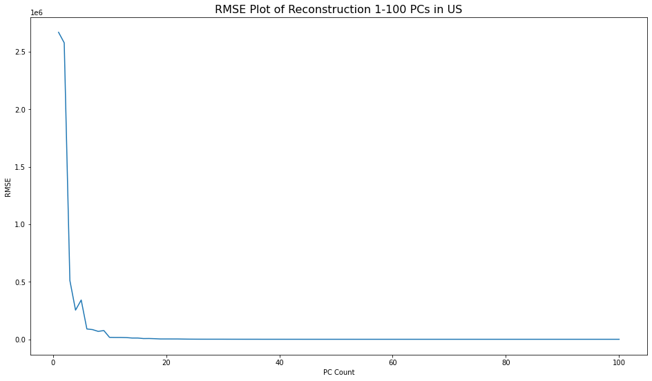

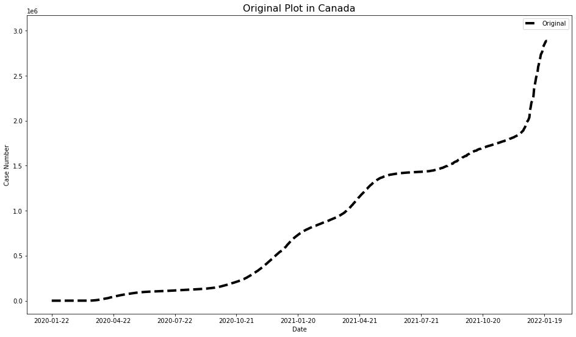

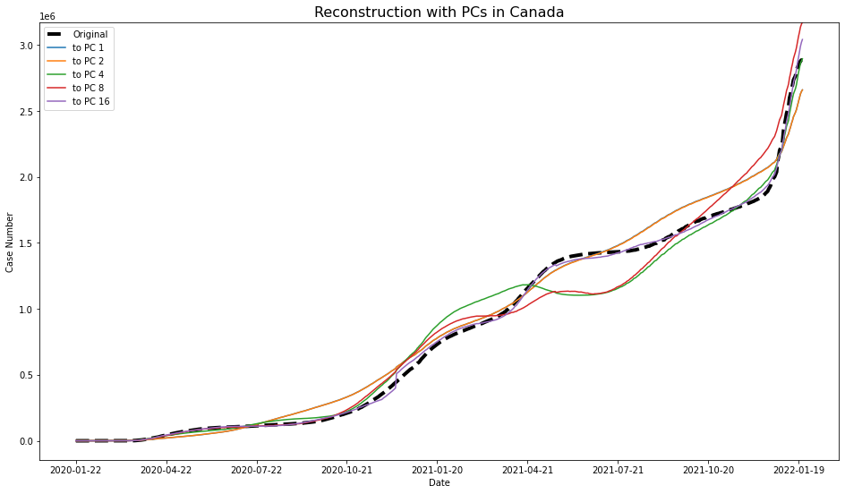

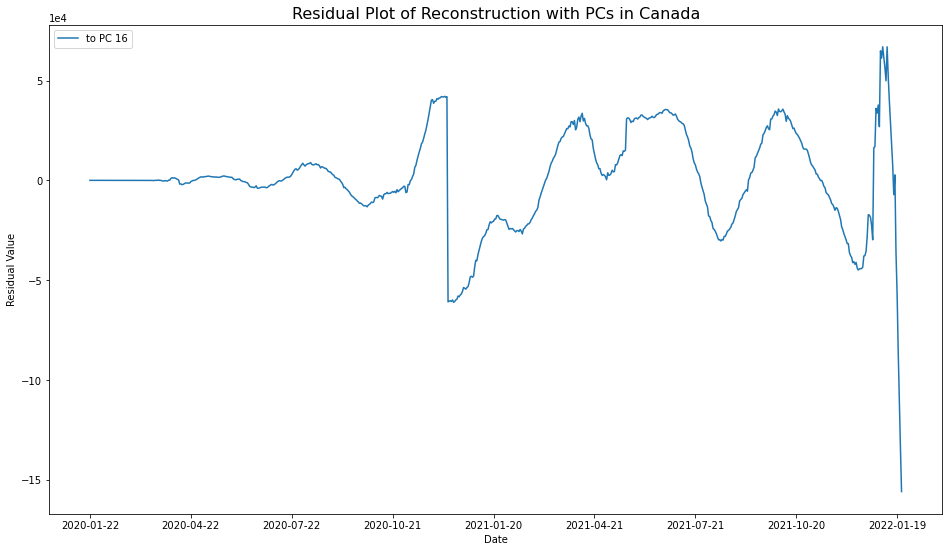

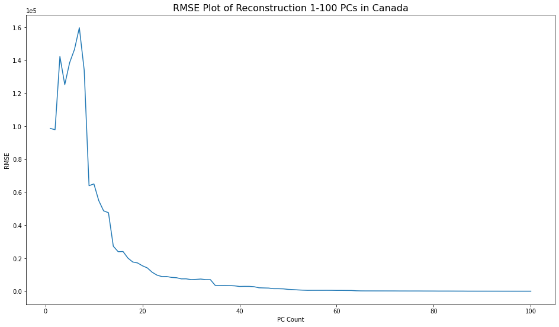

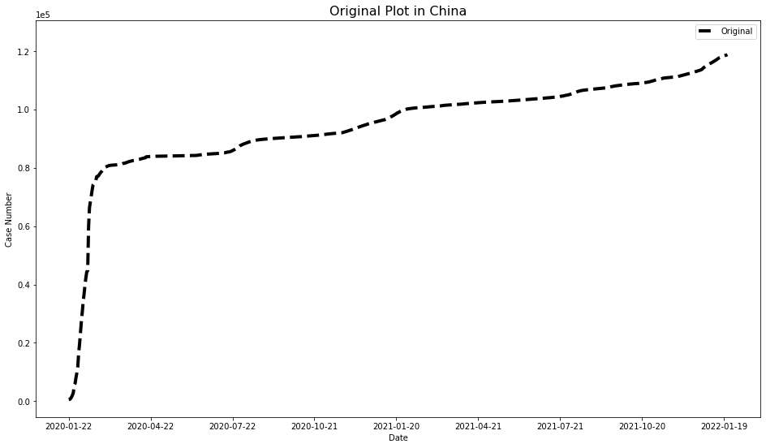

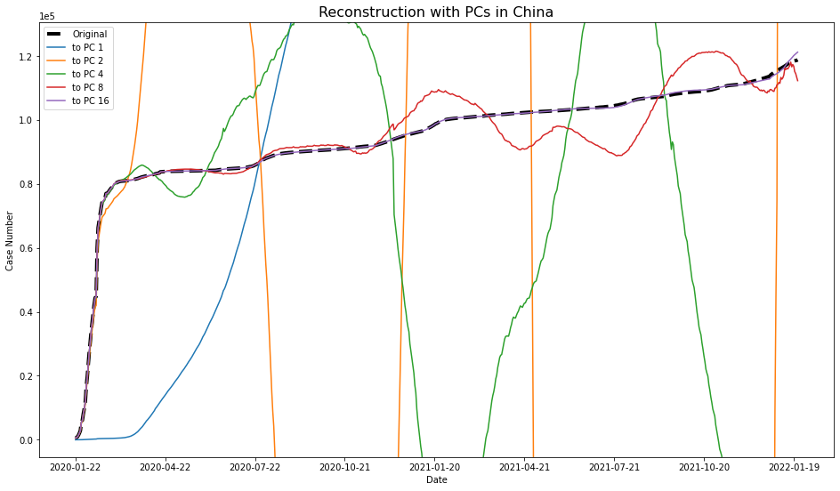

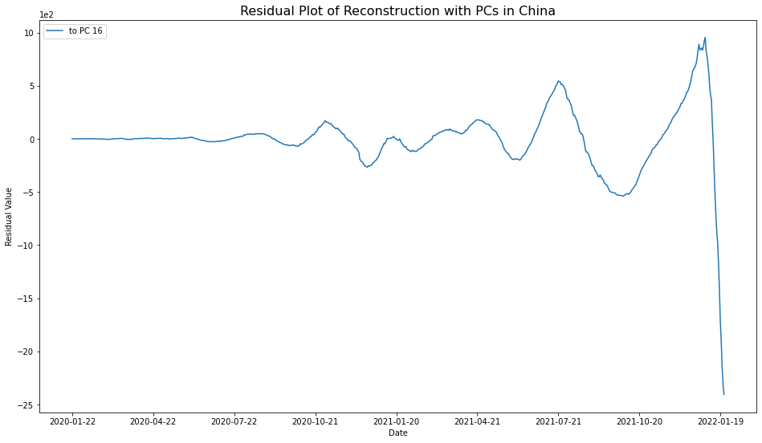

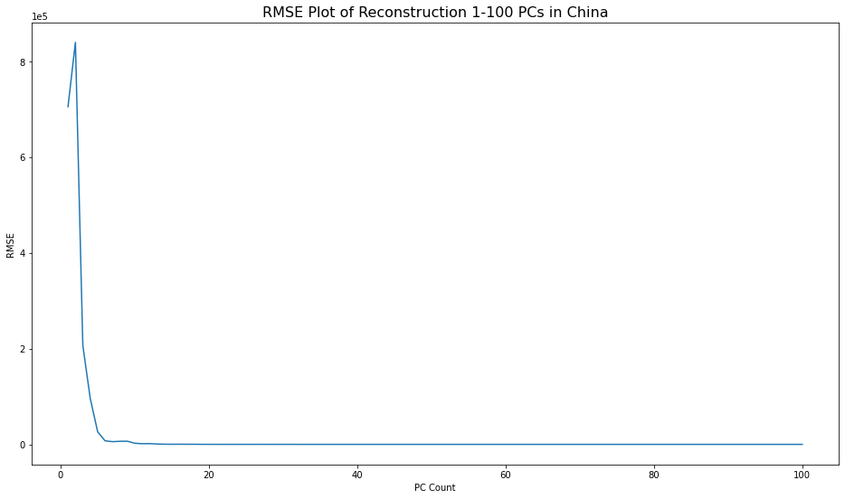

```python
country = ['US', 'Canada', 'China']
for c in country:
    plot_country_figures(cases_raw, c)
```